# Stopping Distance Regression Analysis

Jeff Shamp

2020-04-14

## Regression Analysis Introduction

The data is loaded from the “cars” dataset in R and has values for the stopping distance as a function of speed. It turns out that this is an activity I did with high school physics students for years. As such, I would expect this data to be quadratic, os a garden variety linear regression should not be a great fit and the residuals will likely look like a parabola. Extending the regression to include a squareed term will likely be helpful.

The standard physics approach suggests the following relationship between stopping distance and speed of travel:

$KE = F*d_{stopping}$, such that the Kinetic Energy of car transforms in work done by the tires to stop. This expands to, $\frac{1}{2} m v^{2} = F \times d$. Thus, we expect a squared relationship between speed (*v*) and d (stopping distance).

## Data

Loading tidyverse and datasets libraries.

```r
cars<-datasets::cars
head(cars)
```

```
##   speed dist
## 1     4    2
## 2     4   10
## 3     7    4
## 4     7   22
## 5     8   16
## 6     9   10
```

```r
summary(cars)
```

```
##      speed           dist
##  Min.   : 4.0   Min.   :  2.00
##  1st Qu.:12.0   1st Qu.: 26.00
##  Median :15.0   Median : 36.00
##  Mean   :15.4   Mean   : 42.98
##  3rd Qu.:19.0   3rd Qu.: 56.00
##  Max.   :25.0   Max.   :120.00
```

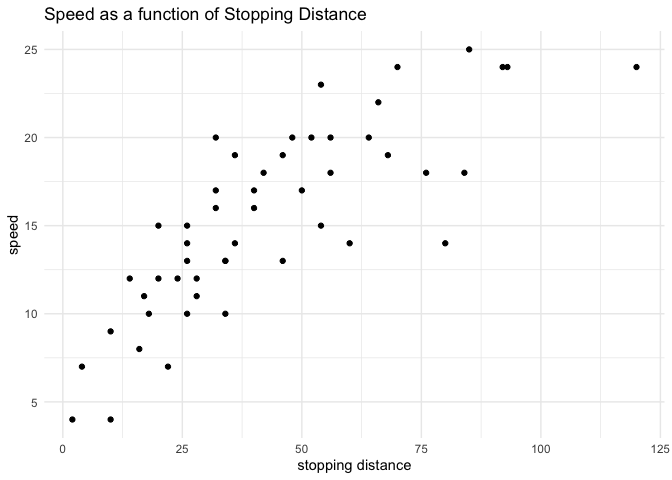

```r
cars %>%
  ggplot(aes(x=dist, y=speed)) +
  geom_point() +
  labs(x="stopping distance",
       y="speed",
       title="Speed as a function of Stopping Distance")
```

## Linear Regression

Apply the regresssion and display some result and metrics.

```r
linreg<- lm(data = cars, speed ~ dist)
linreg
```

```
##
## Call:
## lm(formula = speed ~ dist, data = cars)
##
## Coefficients:
## (Intercept)         dist
##      8.2839       0.1656
```

```r
summary(linreg)
```

```
##
## Call:
## lm(formula = speed ~ dist, data = cars)
##
## Residuals:
##     Min      1Q  Median      3Q     Max
## -7.5293 -2.1550  0.3615  2.4377  6.4179
##
## Coefficients:
##             Estimate Std. Error t value Pr(>|t|)
## (Intercept)  8.28391    0.87438   9.474 1.44e-12 ***
## dist         0.16557    0.01749   9.464 1.49e-12 ***
## ---
## Signif. codes:  0 '***' 0.001 '**' 0.01 '*' 0.05 '.' 0.1 ' ' 1
##
## Residual standard error: 3.156 on 48 degrees of freedom
## Multiple R-squared:  0.6511, Adjusted R-squared:  0.6438
## F-statistic: 89.57 on 1 and 48 DF,  p-value: 1.49e-12
```

Visualize the plot with the regression line applied.

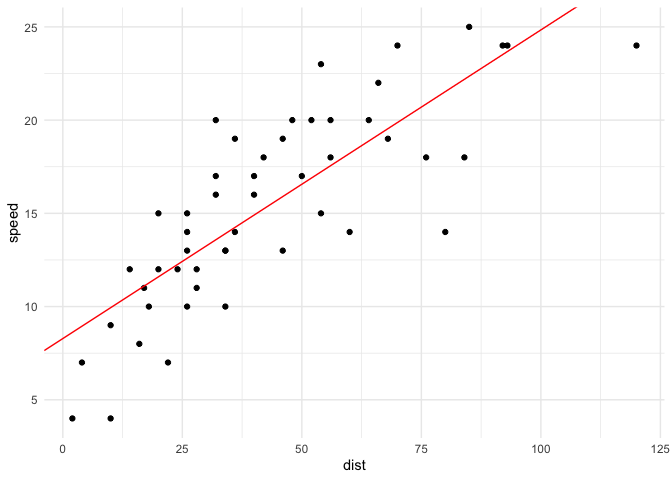

```r
cars %>%
  ggplot(aes(x=dist, y=speed))+
  geom_point(color="black") +
  geom_abline(slope = linreg$coefficients[2],
              intercept = linreg$coefficients[1],
              color="red")
```

### Residual Analysis

We would expect the residuals to be centered around zero for variables that are good linear fits.

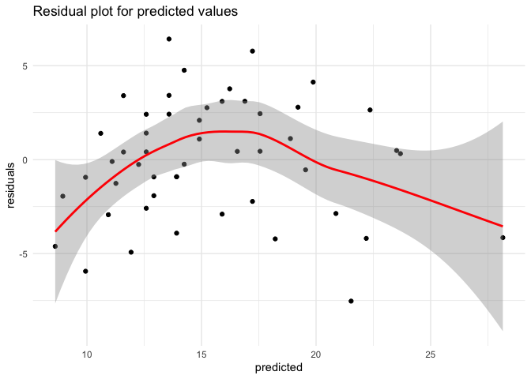

```r
linreg %>%
  ggplot(aes(x=fitted(linreg), y=resid(linreg))) +
  geom_point() +
  geom_smooth(method = "loess", color="red") +
  labs(x="predicted",
       y="residuals",
       title="Residual plot for predicted values")
```

This is rather unconvincing in any direction, It would be nice to see this be more uniform, but it’s not horrible. Let’s also look at the QQ plot.

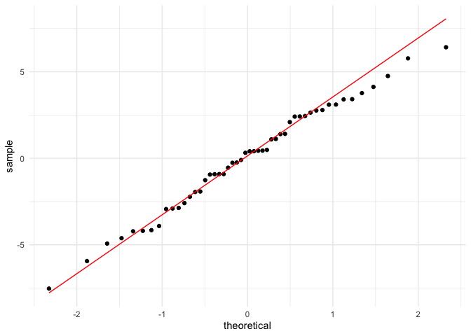

```r
linreg %>%
  ggplot(aes(sample = resid(linreg))) +
  stat_qq() +
  stat_qq_line(color="red")
```